# QMSS G5072 Homework 6

Wenjun Sun

2019-10-22

# Working with Strings

### 0. Install needed packages

### 1. Scrabble

Download a scrabble word list.

```r
data(twl06)
scrabble <- tolower(twl06)  #make sure all words are lower cases
```

#### a) Words with `z`

Select all words that contain at least one `z`. Among the z-words, tabulate how many `z`’s the words contain (i.e. how many words contain one `z`, two `z`’s etc.).

```r
z_words <- str_subset(scrabble, 'z')
str_count(scrabble, 'z') %>% table()
```

```
## .
##      0      1      2      3      4
## 171567   6677    424     16      7
```

#### b) Word lengths

Provide a histogram of the word lengths in the scrabble dictionary.

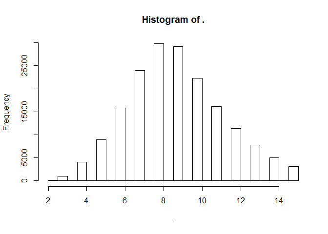

```r
scrabble %>%
  str_length() %>%
  hist()
```

#### c) Vowels

How many words both start and end with a vowel?

```r
sum(str_detect(scrabble, '^[aeiou].*[aeiou]$'))
```

```
## [1] 5075
```

#### d) Longest word with `New York`

What is the longest scrabble word that can be formed just out of the letters contained in “New York” (repetitions of letters are allowed)?

```r
ny_words <- str_subset(scrabble, '^[newyork]+$')
ny_words[nchar(ny_words)==max(nchar(ny_words))]
```

```
## [1] "nonworker"
```

#### e) Consonants only

Find the word(s) with the largest number of consecutive consonants.

```r
# First, get the length of the longest consecutive consonants
n <- scrabble %>% str_extract_all('[^aeiou]+') %>%
                  map(nchar) %>%
                  unlist() %>%
                  max()
# Then, get the word with exactly n consecutive consonants
str_subset(scrabble, paste0('[^aeiou]','{', n, '}'))
```

```
## [1] "dysrhythmia"  "dysrhythmias" "dysrhythmic"  "polyrhythms"
## [5] "sulfhydryls"
```

#### f) Bonuzz (*optional*)

Find the z-word(s) with z’s that are as far apart as possible (i.e. we are interested in the distance between any two z’s in the word). That means the word could contain more than two z’s.

### 2. Emergency Hospital Injuries

The file `emergency.csv` contains a random sample of 10,000 narratives of injuries treated in U.S. emergency departments.

```r
emergency <- read.csv('emergency.csv', header = FALSE, col.names = 'narrative')
emergency$narrative <- tolower(emergency$narrative) #turn all words to lowercase
```

#### a) Fractures

Find all narratives related to “fractures”. Try to include singular/plural/verb forms in your search. How many fracture narratives can you find?

```r
fracture <- ('(fractures|fracture|fract|fractural|fracturing|fractured|fx)')
#I noticed that the narrative used a lot of abbreviations, so I referred to a Nursing Abbreviations, and found that 'Fx' is the the abbreviation of 'fracture'.
narrative_with_fracture <- str_subset(emergency$narrative, pattern = fracture)
head(narrative_with_fracture) # have a look at the fracture narratives
```

```
## [1] "10 mo f fell out of shopping cart;dx fractured skull "
## [2] "8yof fractured finger fell off her bike "
## [3] "12yof fell down stairs dx: fx radius"
## [4] "77 y male had mechanical fall down steps causing ankle inj dx; ankle fx"
## [5] "34yom-fell down indoor steps @ home carrying a dog,tripped on something -fell forward     dx fx distal tibia & fibula"
## [6] "finger fx. 20 yom injured finger when playing basketball "
```

```r
length(narrative_with_fracture) # number of fracture narratives I found
```

```
## [1] 1507
```

#### c) Body Parts

Among the fracture narratives, try to identify the body parts that are fractured (*Note*: Don’t go overboard. A selection of parts is sufficient. No need to become a medicical doctor here). Make a histogram of fractured body parts (but make sure plural and singular are combined.)

```r
#the body parts that I want to include are: ankle, finger, hand, elbow, and arm
bodypart <- c('ankle', 'finger', 'hand', 'elbow', 'arm')

#I create a dataframe for plotting the histogram
df <- data.frame(bodypart)
df$detail <- c(('(ankle|ankles|tibia|tibias|fibula|fibulas|talus)'),
               ('(finger|fingers)'),
               ('(hand|hands)'),
               ('(elbow|elbows)'),
               ('(arm|arms|forearm)'))
for(i in 1:nrow(df)) {
    df$count[i] <- sum(str_detect(narrative_with_fracture, df$detail[i]))
}

head(df) #have a look at the dataframe
```

```
##   bodypart                                           detail count
## 1    ankle (ankle|ankles|tibia|tibias|fibula|fibulas|talus)   187
## 2   finger                                 (finger|fingers)   143
## 3     hand                                     (hand|hands)   142
## 4    elbow                                   (elbow|elbows)    84
## 5      arm                               (arm|arms|forearm)   167
```

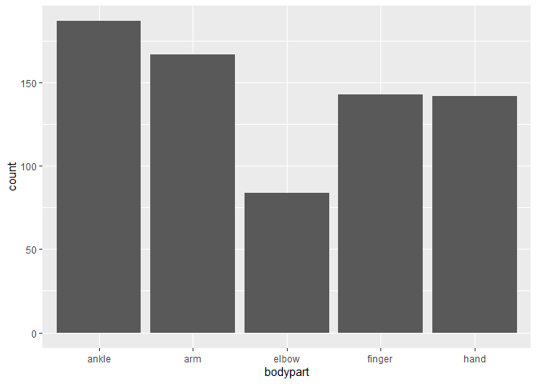

```r
ggplot(df, aes(bodypart, count)) + geom_col()
```

#### d) Age and Gender

Create variables for age and gender (make sure to convert months to years when necessary). How many males and females are in the data? Provide a line graph of the number of injuries (y-axis) vs age (x-axis) disaggregated by gender.

```r
emergency <- read.csv('emergency.csv', header = FALSE, col.names = 'narrative')
emergency$narrative <- tolower(emergency$narrative) #turn all words to lowercase

# I noticed that unites are more than just YO, YR, and MO, there are at least things like Y, M, Y/O, month old, year old, yr old, too. So I think it makes more sense to use 'y' and 'm' as flags.
emergency$id <- str_extract(emergency$narrative, '(\\d+)[ -]*(yo|yr|year old|yr old|y\\/o|y old|yold|y o|y|mo|month old|mo old|month|m|mos)[ -]*(white|black|hisp|w|w\\/)*[ -]*(male|female|m|f)')

# Sanity check
# Listing all narratives that contain number, but are not extracted anything in the previous step
t <- str_subset(emergency[is.na(emergency$id),1], '\\d+')
length(t) #These are the narratives that have numbers but are not found with age infomation.
```

```
## [1] 358
```

```r
# 358 is not much, but I think it's still necessary to see what are they in detail to determine if my regluar expression works well
head(t, n = 10)
```

```
##  [1] "paraplegic pt got burned on buttock 3 weeks ago when nephew was playing with heater. now w/ ulcer. d:decubitus ulcer, buttock."
##  [2] "pt fell down 4 steps, admits to crack cocaine use. dx facial abrasions "
##  [3] "pt inj back while cutting down a tree, 2 weeks ago "
##  [4] "4 m, pt was riding bicycle with training wheels.  fell over into gravel . dx. chin laceration  not wearing helmet"
##  [5] "dx seizure: pt was run'g w he had a witness sz. convulsions. shak'g in all limbs for 15-20 secondes. confusion afterwards"
##  [6] "14 m playing with another friend was accidently kicked in the back with a pair of steel toed boots contusion to lower back"
##  [7] "s/p sustained fall with impact to the forhead in settiong of hypoglycei a episode,fd on the floorbs=34, h/o iddm on ***/***>>lac/hypogly"
##  [8] "10 day old f in grandma's arms when gma tripped over carpet and fell w/ baby in arms. dx: r forehead contusion"
##  [9] "acute lumbar strain-sus inj to lower back after she fell down 6 steps t oday at home."
## [10] "pt was cut w/knife while cooking. dx:  l hand lac 1 cm."
```

```r
#It is too long to display them all in html, but we can see that most numbers have nothing to do with age.
#I already optimized my regular expression several times based on this result, for example I include a race variable to find descriptions like 'white female'.

# prepare a dataframe for cleaning data
info <- str_match(emergency$id, '(\\d+)[ -]*(yo|yr|year old|yr old|y\\/o|y old|yold|y o|y|mo|month old|mo old|month|m|mos)[ -]*(white|black|hisp|w|w\\/)*[ -]*(male|female|m|f)')
emergency <- cbind(emergency, info)
emergency[3] <- NULL
colnames(emergency) <- c('narrative', 'id', 'age_n', 'age_unit', 'race', 'gender')
emergency$age_n <- as.numeric(as.character(emergency$age_n))


#remove narratives with no detected demographic info
emergency <- emergency[!is.na(emergency$id),]

table(emergency$age_unit) #check each age_unit categories before merging them
```

```
##
##         m        mo    mo old     month month old       mos         y
##        17       423        14        16        36         7       362
##       y o       y/o  year old        yo      yold        yr    yr old
##        28       205        13      6790         1       252       235
```

```r
# unify units for age
emergency$age_unit_ym[emergency$age_unit %in% c('mo', 'month old', 'mo old', 'month', 'm', 'mos') ] <- 'm'
emergency$age_unit_ym[emergency$age_unit %in% c('yo', 'yr', 'year old', 'yr old', 'y/o', 'y old', 'yold', 'y o', 'y') ] <- 'y'

#unify gender measure
emergency$gender_malefemale[emergency$gender %in% c('m', 'male') ] <- 'male'
emergency$gender_malefemale[emergency$gender %in% c('f', 'female') ] <- 'female'

#how many males? how many females?
emergency %>% select(gender_malefemale) %>%
              group_by(gender_malefemale) %>%
              summarise(count = n()) %>%
              kable() %>%
              kable_styling(bootstrap_options = "striped")
```

| gender_malefemale | count |
| --- | --- |
| female | 3670 |
| male | 4729 |

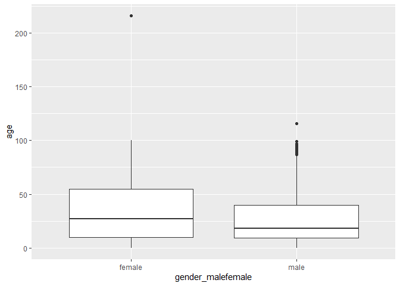

```r
# compute age and prepare a dataframe for plotting
df_part1 <- emergency %>%
            filter(age_unit_ym == 'm') %>%
            mutate(age = round(age_n/12,2)) %>%
            select(gender_malefemale, age, age_n, age_unit_ym, id, narrative)

df_part2 <- emergency %>%
            filter(age_unit_ym == 'y') %>%
            mutate(age = age_n) %>%
            select(gender_malefemale, age, age_n, age_unit_ym, id, narrative)

df <- bind_rows(df_part1,df_part2)

#boxplot
ggplot(df, aes(gender_malefemale, age)) + geom_boxplot()
```

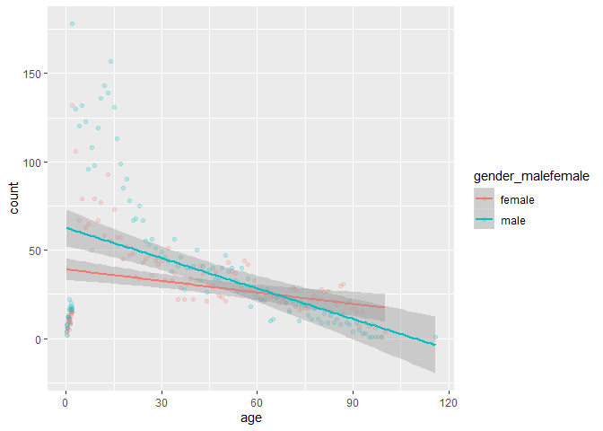

```r
#remove some absurd age data point, Google told me the oldest men in the world is 116 years old.
df <- df[!df$age > 116,]

df %>% group_by(age, gender_malefemale) %>%
               summarise(count = n()) %>%
               ggplot(aes(age, count, group = gender_malefemale, colour = gender_malefemale)) +
               geom_point(alpha = 0.2) +
               geom_smooth(method = lm)
```

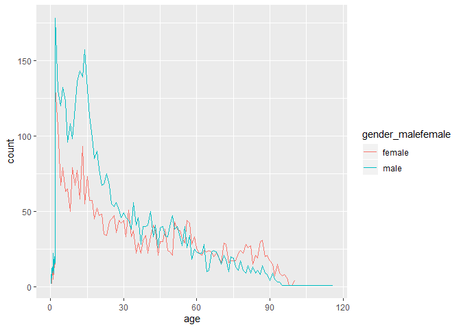

```r
df %>% group_by(age, gender_malefemale) %>%
               summarise(count = n()) %>%
               ggplot(aes(age, count, group = gender_malefemale, colour = gender_malefemale)) +
               geom_line()
```